# Customer Visits - A feature generation exercise

April, 2019

# Introduction

When you first look at the data, it’s tempting to jump quickly to build a classification model by looking at past visits into the upcoming week. The results will look rather depressing. This is a very interesting problem that tests your skills not only in modeling but also in feature engineering.

The data-set provides information about shopping mall visits of 300k customers over the course of 143 weeks. Each line represents one customer - the first column contains a unique customer identifier and the second column contains a vector of the day numbers he/she visited the mall.

The day with index 1 is a Monday (7 is a Sunday, 8 is again a Monday). Indices are within a range of 1 to 1001 (which is equal to 143 full weeks). The task is to predict the first day of the next visit (in week 144).

For instance, if a customer will visit the mall on a Wednesday, then the model should predict 3. We’ll get to this detail later, perhaps in the modeling notebook.

```
##   visitor_id
## 1          1
## 2          2
## 3          3
## 4          4
## 5          5
## 6          6
##                                                                                                              visits
## 1             30 84 126 135 137 179 242 342 426 456 460 462 483 594 600 604 704 723 744 787 804 886 924 928 946 954
## 2  24 53 75 134 158 192 194 211 213 238 251 305 404 418 458 476 493 571 619 731 739 759 761 847 883 943 962 981 983
## 3            51 143 173 257 446 491 504 510 559 616 719 735 769 800 833 853 856 867 882 916 929 937 944 954 956 968
## 4                    1 20 22 92 124 149 211 335 387 390 406 460 489 509 520 600 631 656 761 763 780 788 808 963 985
## 5              34 51 56 106 110 121 163 233 266 275 345 359 380 481 492 505 565 567 630 632 652 656 662 695 794 875
## 6         17 39 145 147 176 187 260 264 288 298 335 339 481 540 561 571 614 668 676 759 797 806 836 884 887 956 962
```

# Data peek

Let’s look at the data to see what sense we can make out of it. The visits column basically has a character dump of all visits. We’ll keep a list of vectors so we can use it to wrangle and create some new features.

## Distribution of visits

It’s interesting to see how many visits one has made in the span of the 143 weeks.

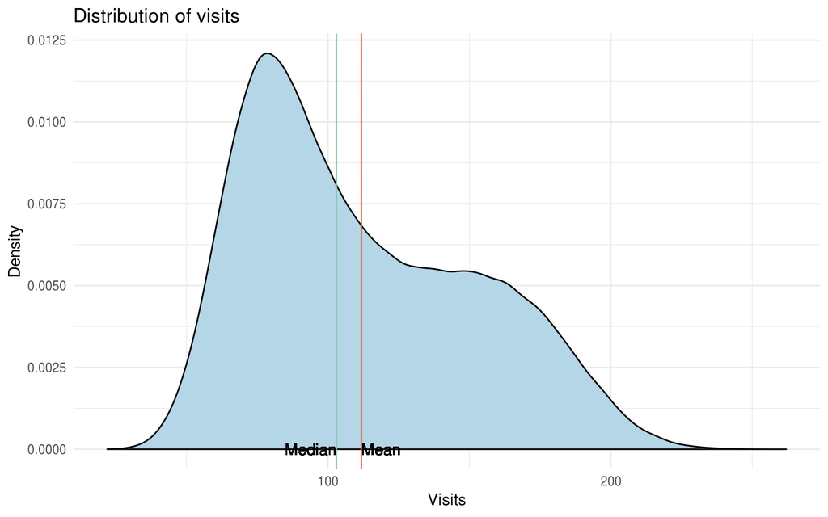

## Visits over the days of the week

A shopping mall typically will have a rush over the weekends. Let’s see if that hypothesis is true in our case.

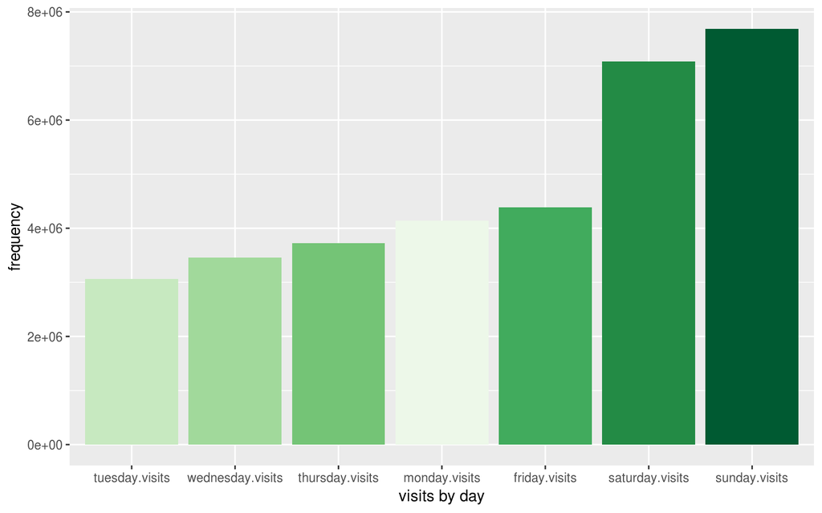

## Interval between visits

Understanding the typical gap between visits of a customer can be a crucial indicator to predicting the next visit of a customer. The below shows the distribution of customers’ interval between visits. We can take the 95 percentile cut-off as the number of days (recent) to train our model instead of the entirety of the data-set.

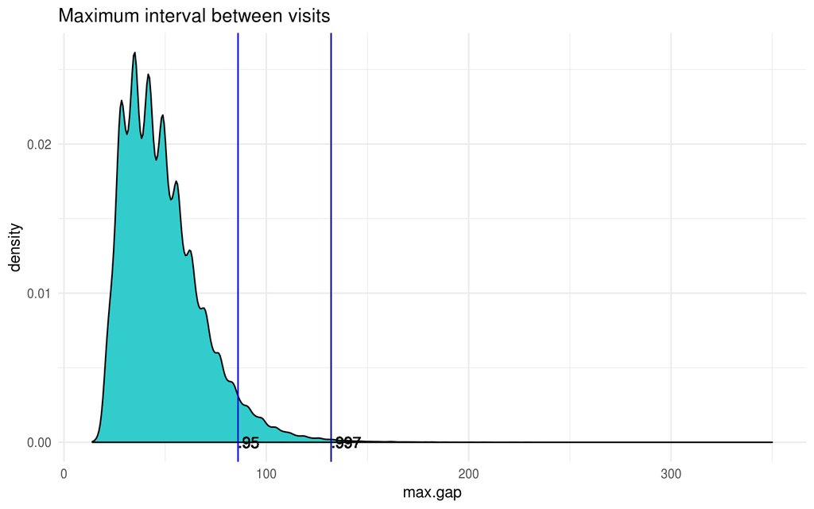

# Feature engineering

The next stages will involve transforming the data into a format usable for modeling and create some interesting features that might explain a customer visit pattern.

## Making a usable data frame

The current data is not easy to understand for the computer. Let’s first make it into a usable data frame. From the above table, you can notice that there is leading white-space followed by a set of numbers separated by a space. Since we have to do this 300000 times, let’s use the capability of all the cores to speed this up a little bit.

```
##   visitor.id visit.day
## 1          1        30
## 2          1        84
## 3          1       126
## 4          1       135
## 5          1       137
## 6          1       179
```

## Days of the week

Let’s convert the raw numbers to something more meaningful. Each day number is available to us. Let’s create some interesting features - 1. Day of the week 2. Week number 3. Binary to indicate which day of the week a visit happened

```
##   visitor.id visit.day day.of.week week.number Tue Sun Thu Sat Mon Fri Wed
## 1          1        30           2           5   1   0   0   0   0   0   0
## 2          1        84           7          12   0   1   0   0   0   0   0
## 3          1       126           7          18   0   1   0   0   0   0   0
## 4          1       135           2          20   1   0   0   0   0   0   0
## 5          1       137           4          20   0   0   1   0   0   0   0
## 6          1       179           4          26   0   0   1   0   0   0   0
```

## Visit patterns

While exploring the data we found that weekends visits are considerable higher than weekdays. We want to understand how over time a customer visit pattern changes. It makes sense to look at the level of data at a customer-week level. Doing so will increase the size of the data substantially. So far looking at the data, all columns are numbers - no decimals. We can keep them as integers instead of numeric to save some memory.

We’ll derive the next set of features - 1. Visits by week-day level 2. Non-visits data - We’ll have to remove non-visits of a customer before he first visited. We wouldn’t want our model to learn that. 3. Total visits in a week 4. Cumulative frequency of visits at a customer week level

[output not shown]

```
## # A tibble: 6 x 13
## # Groups:   visitor.id [1]
##   visitor.id week.number   Mon   Tue   Wed   Thu   Fri   Sat   Sun
##        <int>       <int> <int> <int> <int> <int> <int> <int> <int>
## 1          1           5     0     1     0     0     0     0     0
## 2          1           6     0     0     0     0     0     0     0
## 3          1           7     0     0     0     0     0     0     0
## 4          1           8     0     0     0     0     0     0     0
## 5          1           9     0     0     0     0     0     0     0
## 6          1          10     0     0     0     0     0     0     0
## # … with 4 more variables: total.visits.in.week <int>, frequency <int>,
## #   any.visit <int>, no.visit <int>
```

## Proportions of visits, non-visits, gap

Customers are likely to spike their visits to a shopping mall on weekends. Using the above let’s look at how the proportions of visits have been changing with respect to days of the week. Understanding the inter visit interval is also important to understand when one is likely to visit.

Key features below - 1. Weeks since the last visit 2. Total visits/non-visits by day of the week 3. Proportions of visits by day of the week

```
## # A tibble: 6 x 30
## # Groups:   visitor.id [1]
##   visitor.id week.number   Mon   Tue   Wed   Thu   Fri   Sat   Sun
##        <int>       <int> <int> <int> <int> <int> <int> <int> <int>
## 1          1           5     0     1     0     0     0     0     0
## 2          1           6     0     0     0     0     0     0     0
## 3          1           7     0     0     0     0     0     0     0
## 4          1           8     0     0     0     0     0     0     0
## 5          1           9     0     0     0     0     0     0     0
## 6          1          10     0     0     0     0     0     0     0
## # … with 21 more variables: total.visits.in.week <int>, frequency <int>,
## #   any.visit <int>, no.visit <int>, weeks.since.visit <int>,
## #   Tot.Mon <int>, Tot.Tue <int>, Tot.Wed <int>, Tot.Thu <int>,
## #   Tot.Fri <int>, Tot.Sat <int>, Tot.Sun <int>, Tot.no.visit <int>,
## #   prop.no.visit <dbl>, prop.Sun <dbl>, prop.Mon <dbl>, prop.Tue <dbl>,
## #   prop.Wed <dbl>, prop.Thu <dbl>, prop.Fri <dbl>, prop.Sat <dbl>
```

# Next steps

Now that we have a complete data-set we’ll use the cut-off from the maximum visit interval to define my training period and build a model. We’ll keep the modeling exercise in another notebook.